# Classic latent vs. spectrum model structures for tuberculosis natural history

A reproducible structural comparison

## The question

Dynamic models of tuberculosis differ in a structural choice that is usually made implicitly: how an infected person progresses to disease. Two families are in wide use.

The **classic latent-progression** family, catalogued by @menzies2018 across 312 published models, routes infection through one or two latent compartments to a single active-disease state. Its twelve variants (A–L) differ only upstream of disease.

The **spectrum** family, developed by @richards2023 and @horton2023, resolves disease itself into **minimal** (pre-infectious), **subclinical** (bacteriologically positive, asymptomatic) and **clinical** (positive, symptomatic) states, with movement in both directions.

This document compares the families on three questions: (a) their fit to natural-history cohort data, (b) the subclinical fraction they imply, and (c) the impact they predict for community-wide screening. The full design, data inventory, and the reasoning behind fitting the families to overlapping (not identical) blocks of data are in `PLAN.md` and `docs/likelihood_blocks.html`.

## Model structures

|  | structure | family | compartments | free_params | notes |
| --- | --- | --- | --- | --- | --- |
| 0 | A | classic | 5 | 3 | Constant progression hazard; special case of E... |
| 1 | B | classic | 8 | 5 | Fast-latent tunnel (3 states) then slow latent. |
| 2 | C | classic | 6 | 5 | Fast/slow latent in series; special case of G ... |
| 3 | D | classic | 4 | 2 | Immediate progression for all; used only for a... |
| 4 | E | classic | 5 | 4 | The standard Blower-type fast/slow split (49% ... |
| 5 | F | classic | 6 | 5 | Parallel fast/slow latent compartments, no tra... |
| 6 | G | classic | 6 | 6 | Structure C plus immediate progression. |
| 7 | H | classic | 6 | 5 | Progression only from Lf; Ls feeds Lf. |
| 8 | I | classic | 6 | 5 | Progression only from Lf; reversible Lf<->Ls. |
| 9 | J | classic | 8 | 4 | Sequential latent chain (4); risk rises with t... |
| 10 | K | classic | 5 | 4 | Single latent; hazard x1*max(1,t)^x2 (Blaser 2... |
| 11 | L | classic | 5 | 5 | Single latent; hazard x1*(x2+exp(-x3 t)). |
| 12 | SP-full | spectrum | 7 | 10 | Spectrum model (min=True, clear=True). |
| 13 | SP-noclear | spectrum | 6 | 9 | Spectrum model (min=True, clear=False). |
| 14 | SP-nomin | spectrum | 6 | 7 | Spectrum model (min=False, clear=True). |
| 15 | SP-nomin-noclear | spectrum | 5 | 6 | Spectrum model (min=False, clear=False). |

All sixteen structures are implemented in one declarative engine: a structure is a list of compartments and transitions, and the cohort simulator, the differentiable likelihood, and the transmission embedding all read those lists generically (see the README for how to add one). The twelve classic structures are transcribed from Figure 1 of @menzies2018; the four spectrum variants are the @horton2023 main model and three ablations (without the minimal state, without self-clearance of infection, and without both).

## Validation: reproducing the published posteriors

Calibrating the full spectrum model to its own cohort data reproduces the @horton2023 posterior. Under NUTS, all nine parameters’ 95% credible intervals overlap the published values, and the shared downstream rates also match the @richards2023 table.

|  | param | mine_median | mine_q2.5 | mine_q97.5 | horton_median | horton_lo | horton_hi | richards_median | CrI_overlaps_horton |
| --- | --- | --- | --- | --- | --- | --- | --- | --- | --- |
| 0 | infclr | 1.101 | 0.830 | 1.423 | 1.83 | 0.94 | 3.30 | NaN | True |
| 1 | infmin | 0.070 | 0.040 | 0.111 | 0.10 | 0.04 | 0.23 | NaN | True |
| 2 | infsub | 0.026 | 0.014 | 0.043 | 0.04 | 0.01 | 0.10 | NaN | True |
| 3 | minrec | 0.172 | 0.124 | 0.225 | 0.18 | 0.14 | 0.23 | 0.19 | True |
| 4 | min_sub | 0.229 | 0.196 | 0.270 | 0.24 | 0.20 | 0.28 | 0.25 | True |
| 5 | sub_min | 1.563 | 1.157 | 2.137 | 1.58 | 1.22 | 2.05 | 1.50 | True |
| 6 | sub_clin | 0.662 | 0.491 | 0.925 | 0.72 | 0.56 | 0.95 | 0.69 | True |
| 7 | clin_sub | 0.596 | 0.472 | 0.766 | 0.58 | 0.46 | 0.73 | 0.58 | True |
| 8 | mort | 0.351 | 0.296 | 0.406 | 0.33 | 0.28 | 0.38 | 0.33 | True |

The production fits use MAP estimation with a Laplace approximation, which is fast and yields a direct identifiability diagnostic; the SP-full MAP lands on the same posterior.

## (a) Fit to natural-history cohort data

Both families predict the cumulative incidence of **infectious** disease by time since infection, so they are compared head-to-head on that shared curve (the NTI Bangalore converter cohorts and the Ferebee 1970 reactivation curve). The table ranks structures by WAIC on those observations (lower is better); `duration` is the model-implied mean duration of infectious disease, a prediction.

|  | structure | family | n_params | waic_shared_converters | p_waic | n_obs | duration_infectious_med | duration_lo | duration_hi | condition_number | well_constrained_params |
| --- | --- | --- | --- | --- | --- | --- | --- | --- | --- | --- | --- |
| 0 | G | classic | 6 | 5174.11 | 10.15 | 21 | 1.10 | 0.64 | 1.61 | 1514.0 | 4 |
| 1 | F | classic | 5 | 5175.28 | 10.70 | 21 | 1.08 | 0.69 | 1.59 | 57.3 | 4 |
| 2 | H | classic | 5 | 5175.30 | 10.72 | 21 | 1.08 | 0.69 | 1.59 | 58.6 | 4 |
| 3 | B | classic | 5 | 5175.33 | 10.50 | 21 | 1.08 | 0.69 | 1.59 | 115.8 | 4 |
| 4 | L | classic | 5 | 5176.20 | 11.52 | 21 | NaN | NaN | NaN | 130098.8 | 4 |
| 5 | C | classic | 5 | 5176.52 | 11.54 | 21 | 1.08 | 0.69 | 1.59 | 110.8 | 4 |
| 6 | I | classic | 5 | 5176.53 | 11.59 | 21 | 1.08 | 0.69 | 1.59 | 168.8 | 4 |
| 7 | SP-full | spectrum | 10 | 5206.20 | 22.59 | 21 | 0.94 | 0.72 | 1.23 | 239.1 | 9 |
| 8 | K | classic | 4 | 5399.75 | 56.74 | 21 | 1.09 | 0.72 | 1.64 | 97.0 | 3 |
| 9 | SP-nomin | spectrum | 7 | 5462.19 | 65.16 | 21 | 1.06 | 0.05 | 23.69 | 5056.5 | 2 |
| 10 | SP-nomin-noclear | spectrum | 6 | 6530.48 | 174.48 | 21 | 1.17 | 0.06 | 41.95 | 2321.2 | 1 |
| 11 | SP-noclear | spectrum | 9 | 6543.49 | 171.52 | 21 | 0.89 | 0.69 | 1.18 | 287.4 | 8 |
| 12 | A | classic | 3 | 6589.23 | 207.24 | 21 | 1.12 | 0.69 | 1.63 | 85.8 | 2 |
| 13 | E | classic | 4 | 6608.37 | 213.55 | 21 | 1.08 | 0.62 | 1.67 | 1173.0 | 2 |
| 14 | J | classic | 4 | 6622.70 | 218.47 | 21 | 1.08 | 0.62 | 1.67 | 258.6 | 3 |
| 15 | D | classic | 2 | 21552.20 | 0.00 | 21 | 1.08 | 0.65 | 1.66 | 32.8 | 1 |

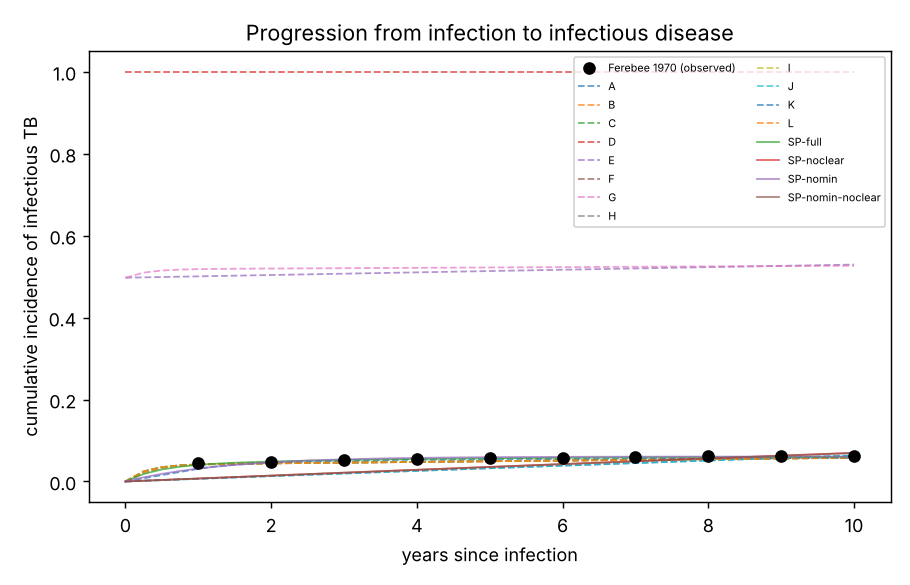

Cumulative incidence of infectious TB by time since infection: each structure’s median fit against the Ferebee 1970 observed curve.

### Identifiability

A recurring message of @menzies2018 is that many structures are over-parameterised relative to the data. The Laplace Hessian makes this concrete: the condition number of the posterior and the per-parameter prior-to-posterior contraction show which parameters the cohort data actually constrain.

|  | structure | n_params | condition_number | well_constrained |
| --- | --- | --- | --- | --- |
| 3 | D | 2 | 32.8 | 1 |
| 5 | F | 5 | 57.3 | 4 |
| 7 | H | 5 | 58.6 | 4 |
| 0 | A | 3 | 85.8 | 2 |
| 10 | K | 4 | 97.0 | 3 |
| 2 | C | 5 | 110.8 | 4 |
| 1 | B | 5 | 115.8 | 4 |
| 8 | I | 5 | 168.8 | 4 |
| 12 | SP-full | 10 | 239.1 | 9 |
| 9 | J | 4 | 258.6 | 3 |
| 13 | SP-noclear | 9 | 287.4 | 8 |
| 4 | E | 4 | 1173.0 | 2 |
| 6 | G | 6 | 1514.0 | 4 |
| 15 | SP-nomin-noclear | 6 | 2321.2 | 1 |
| 14 | SP-nomin | 7 | 5056.5 | 2 |
| 11 | L | 5 | 130098.8 | 4 |

## (b) Subclinical fraction (hold-out)

Prevalence surveys find that roughly half to two-thirds of bacteriologically positive TB is asymptomatic (subclinical). This is a quantity only the spectrum family produces directly; a classic model’s single active-disease state has no subclinical/clinical distinction.

|  | structure | family | country | model_subclinical_fraction | survey_subclinical_fraction |
| --- | --- | --- | --- | --- | --- |
| 0 | A | classic | Viet Nam | n/a (single disease state) | 0.66-0.7 |
| 1 | A | classic | South Africa | n/a (single disease state) | 0.577-0.577 |
| 2 | A | classic | India | n/a (single disease state) | 0.4-0.62 |
| 3 | A | classic | Kenya | n/a (single disease state) | 0.4-0.62 |
| 4 | A | classic | Netherlands | n/a (single disease state) | 0.4-0.62 |
| ... | ... | ... | ... | ... | ... |
| 65 | SP-nomin-noclear | spectrum | Viet Nam | 0.85 | 0.66-0.7 |
| 66 | SP-nomin-noclear | spectrum | South Africa | 0.832 | 0.577-0.577 |
| 67 | SP-nomin-noclear | spectrum | India | 0.83 | 0.4-0.62 |
| 68 | SP-nomin-noclear | spectrum | Kenya | 0.822 | 0.4-0.62 |
| 69 | SP-nomin-noclear | spectrum | Netherlands | n/a (single disease state) | 0.4-0.62 |

70 rows × 5 columns

## (c) Community-wide screening: the ACT3 trial

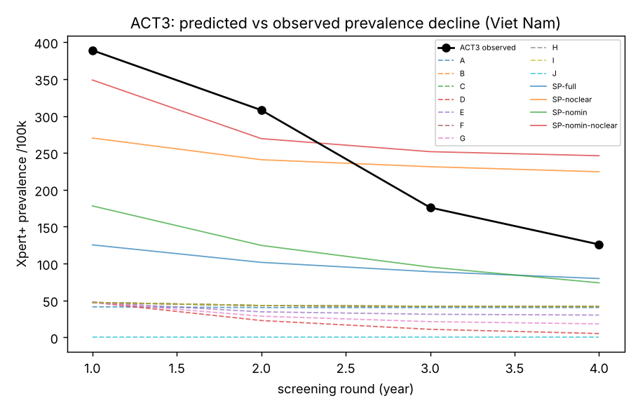

ACT3: predicted vs observed Xpert-positive prevalence decline over the three screening rounds and the year-4 survey (Viet Nam).

|  | structure | family | round | model_prevalence | observed_prevalence |
| --- | --- | --- | --- | --- | --- |
| 0 | A | classic | 1 | 41.5 | 389.0 |
| 1 | A | classic | 2 | 40.5 | 308.0 |
| 2 | A | classic | 3 | 40.5 | 176.0 |
| 3 | A | classic | 4 | 40.6 | 126.0 |
| 4 | A | classic | control_y4 | 41.5 | 226.0 |
| ... | ... | ... | ... | ... | ... |
| 65 | SP-nomin-noclear | spectrum | 1 | 348.8 | 389.0 |
| 66 | SP-nomin-noclear | spectrum | 2 | 269.4 | 308.0 |
| 67 | SP-nomin-noclear | spectrum | 3 | 251.7 | 176.0 |
| 68 | SP-nomin-noclear | spectrum | 4 | 246.2 | 126.0 |
| 69 | SP-nomin-noclear | spectrum | control_y4 | 348.8 | 226.0 |

70 rows × 5 columns

## Transmission fits to GBD, and the duration tension

Each structure is embedded in a transmission model, its natural-history parameters fixed at the cohort fit, and beta is fitted to GBD TB incidence in five countries spanning SDI and HIV burden. Active-TB prevalence, deaths, LTBI prevalence and the subclinical fraction are then **predictions**.

The prevalence-to-incidence ratio is where structure bites. The spectrum parameters of @horton2023 and @richards2023 imply rapid regression out of bacteriologically positive disease, so point prevalence of Xpert-positivity is low for a given incidence — the models under-predict GBD active-TB prevalence several-fold. This is the same tension the ACT3 simulation exposes, and it is a genuine, reportable property of the published spectrum natural history, not a fitting artefact.

## Reproducibility

Every input is fetched at a pinned version (`fetch_data.py`); all posteriors, fits and simulations regenerate from `scripts/`; and the DuckDB file `results/tb_model_structures.duckdb` holds every input, posterior and output. GBD estimates are model outputs used as fitting targets, never as validation.